# projekt

Filip Konić i Jakov Sergo

2/1/2019

U ovom izvještaju predstavljena je grafička analiza tri podatkovna skupa vezanih za popularni serijal “Igra Prijestolja”.

Prvi podatkovni skup sadrži informacije o bitkama koje su se dogodile u prvih pet knjiga serijala.

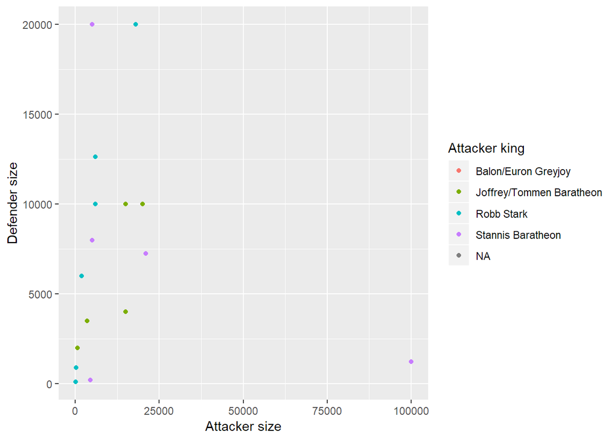

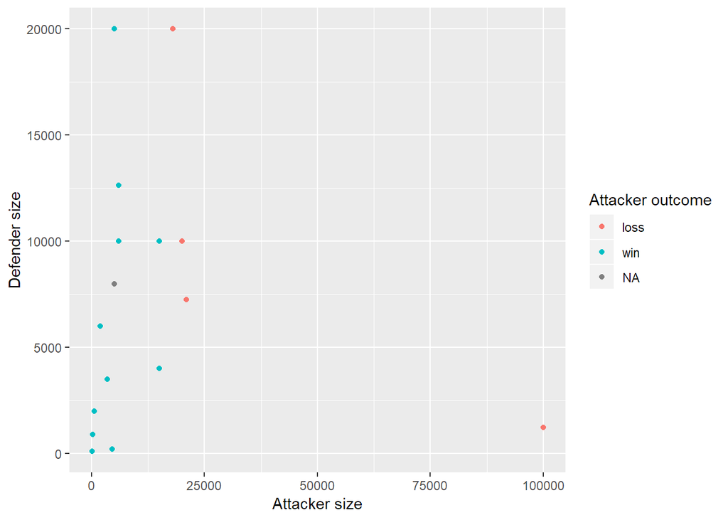

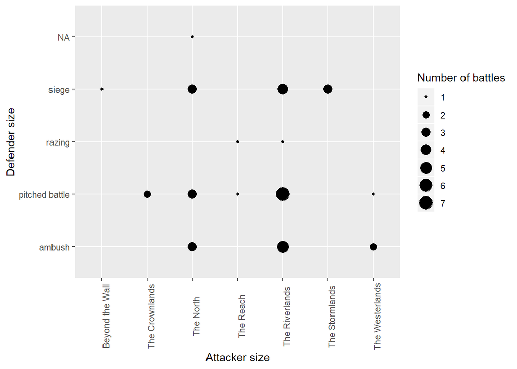

Iz navedenih grafova možemo uvidjeti par kontraintuitivnih činjenica, a to da je lakše napadati nego se braniti (omjer pobjeda napadača i branitelja je 11 naprema 4) te da veličina vojske ima malu korelaciju sa ishodom bitke. Također je moguće uvidjeti da se najviše sukoba odvijalo u Riverlandsima, te da je najviše bitaka zapravo bilo ugovoreno.

Kao drugi podatkovni skup imamo popis svih umrlih likova koji se spominju u knjigama.

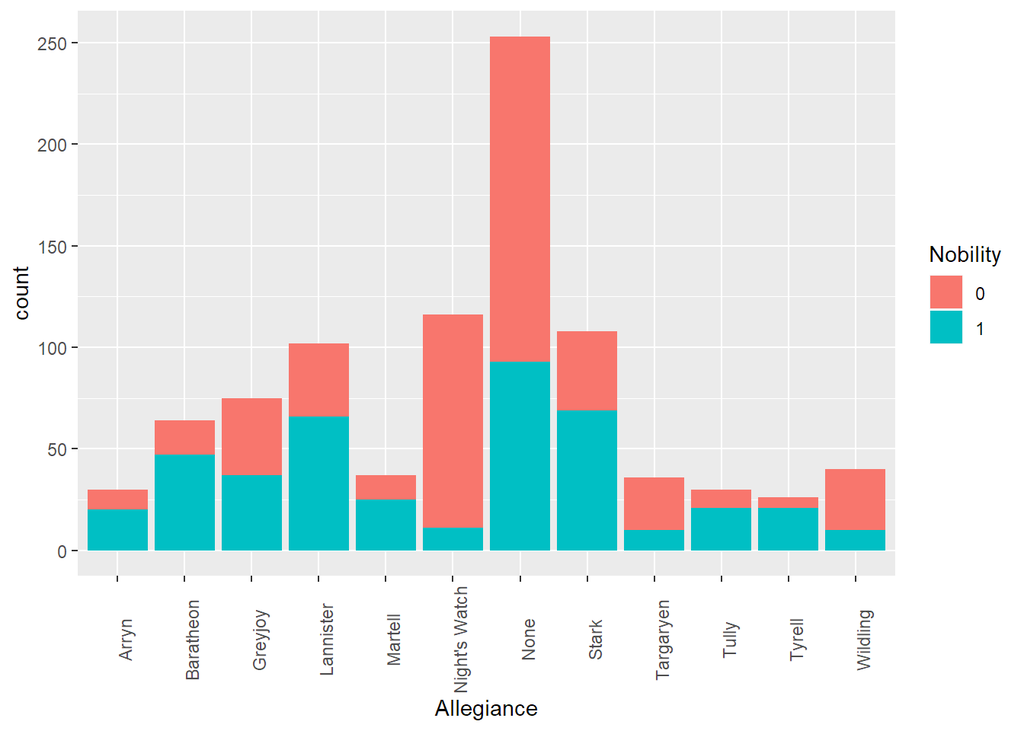

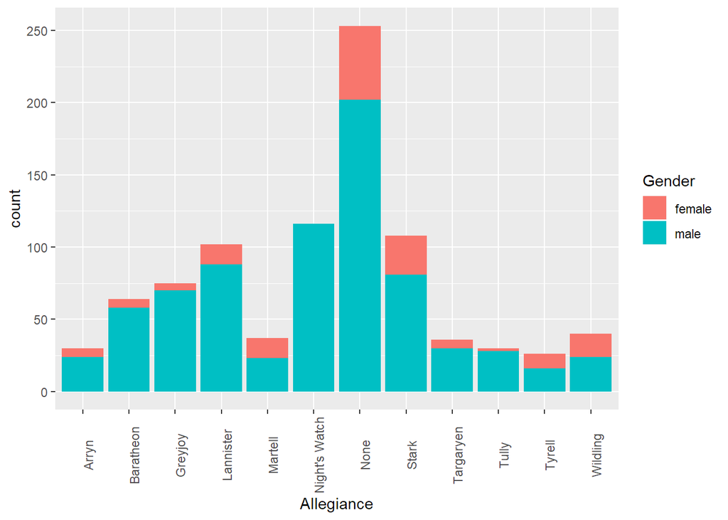

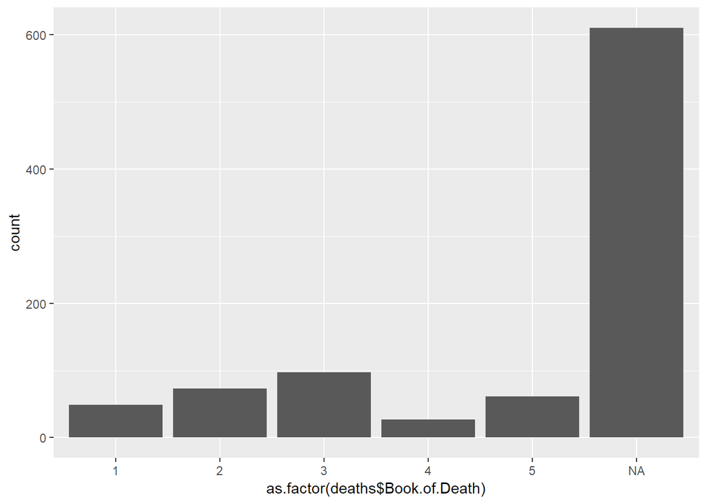

Iz grafova možemo iščitati da je najviše likova spomenutih u knjigama zapravo umrlo van vremena koje knjige obrađuju, ali od onih koji su umrli u knjigama, najviše ih je umrlo u 3. knjizi (vjerojatno zbog *Red Weddinga*).

Treći obrađeni podatkovni skup su rejtinzi za poglavlja knjiga iz serijala “Pjesme Leda i Vatre”.

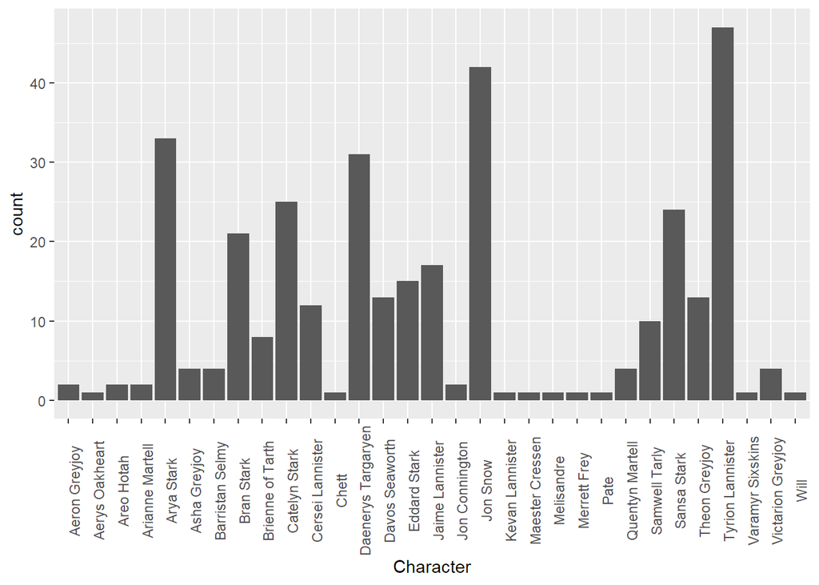

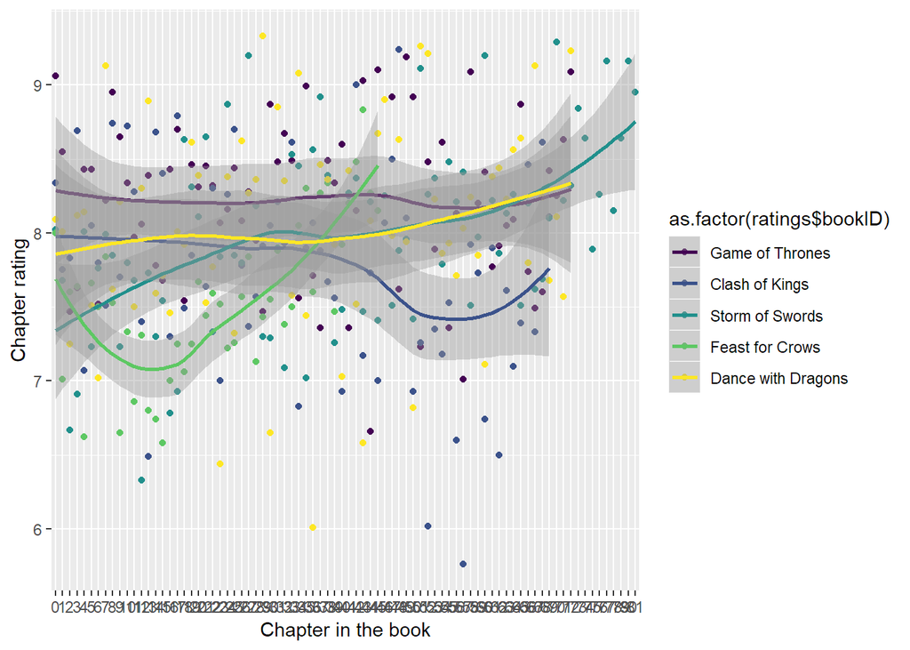

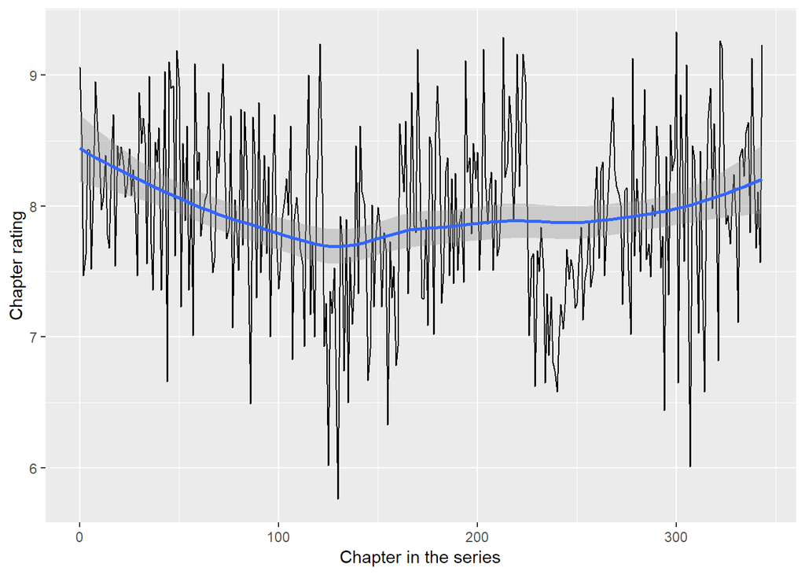

Iz priloženog je uočljivo da je Tyrion Lannister “najrazgovorljiviji” pripovjedač u serijalu, te je uočljiv trend da se svakoj knjizi zanimljivija poglavlja nalaze pri kraju same knjige (takozvani cliffhangeri) te kada promatramo cijeli serijal možemo uočiti kako su početak i kraj serijala zanimljiviji od većeg, središnjeg dijela knjige.